# CITE-seq: ARN y proteína en la misma célula

Por qué los datos de proteína no se pueden tratar como los de ARN, y cómo se combinan las dos modalidades

Dr. Danilo Ceschin

Bioinformática y Estadística 3 · Licenciatura en Ciencias Genómicas

Clase 4 de 4 · 24 de septiembre de 2026

## Anotamos linfocitos T CD4 sin poder ver CD4

Retomamos el problema abierto de la clase 3

Los marcadores canónicos de inmunología son **proteínas de superficie**. Nosotros medimos ARNm, y la correlación entre ambos es moderada.

`CD4` es el caso de manual: su ARNm casi no se detecta en scRNA-seq aunque la proteína esté ahí. Usamos `IL7R` como sustituto. Funcionó, pero era un sustituto.

Lo que cambia hoy

#### CITE-seq mide las dos cosas en la misma célula

Un vector de expresión génica **y** un vector de abundancia de proteínas de superficie, para cada célula.

## La tecnología

01

Cómo funciona CITE-seq.

## Cómo funciona CITE-seq

La tecnología

*Cellular Indexing of Transcriptomes and Epitopes by Sequencing* (Stoeckius et al., 2017).

**1 · Anticuerpos conjugados a un oligo con código de barras**  
Son los **ADT**, *antibody-derived tags*. Cada anticuerpo del panel lleva su propia secuencia identificatoria.

**2 · Se tiñen las células, como en citometría**  
Y se lavan para eliminar el anticuerpo no unido. En teoría.

**3 · Encapsulación en gotas junto con las perlas de captura**  
El código de barras de la célula se agrega tanto al ARNm como al oligo del ADT.

**4 · Dos librerías separadas, un mismo código de barras celular**  
Se secuencian por separado y se reúnen computacionalmente.

**5 · Resultado: dos vectores por célula**  
Expresión génica (~30.000 features) y abundancia de proteínas de superficie (10–300 features).

## ARN y ADT tienen estructuras de ruido opuestas

La diferencia que organiza toda la clase

ARN

#### El problema es no ver lo que está

~20.000–30.000 features · miles de conteos por célula · 90–95 % de ceros.

Ruido dominante: **dropout**.

ADT (proteína)

#### El problema es ver lo que no está

10–300 features (el panel lo eliges tú) · decenas de miles de conteos por célula · sparsity baja: casi todo tiene señal.

Ruido dominante: **fondo**.

`nFeature_ADT` es casi siempre 17 de 17 en un panel de 17 anticuerpos: cada célula tiene señal de todos. En ARN eso sería impensable.

## Cuatro decisiones que se toman antes del experimento

Diseño experimental

Decisión 1

#### El panel

De 10 a 300 anticuerpos. Es irreversible: lo que no pusiste, no lo puedes medir después. Un panel chico y bien elegido vale más que uno grande y genérico.

Decisión 2

#### Controles isotipo

Anticuerpos que no se unen a nada específico, del mismo isotipo. Su señal **es** el fondo inespecífico. Deberían estar en todo panel; muchos datasets públicos no los tienen.

Decisión 3

#### Cell hashing

Anticuerpos contra proteínas ubicuas, con un código por muestra. Permiten multiplexar varias muestras en un carril e identificar doublets entre muestras. Seurat: `HTODemux()`.

Decisión 4

#### Qué NO se puede medir

Solo proteínas de **superficie**. Nada intracelular, nada de fosfoproteínas, nada de modificaciones postraduccionales.

## El fondo

02

Las gotas vacías tienen señal de proteína — y eso lo cambia todo.

## Gotas sin célula, con cientos de conteos de ADT

La observación central

Si la tinción y el lavado fueran perfectos, deberían tener cero.

99,9 %de los códigos de barras de la matriz raw son gotas vacías: 7.865 células de 6.794.880

~8conteos de ARN (mediana) en esas gotas: efectivamente no contienen célula

~260conteos de ADT (mediana) en esas mismas gotas vacías; una célula típica tiene ~5.800

El origen: anticuerpos que quedaron libres en la suspensión después del lavado, y se reparten por todas las gotas.

## El fondo, anticuerpo por anticuerpo

En nuestros datos

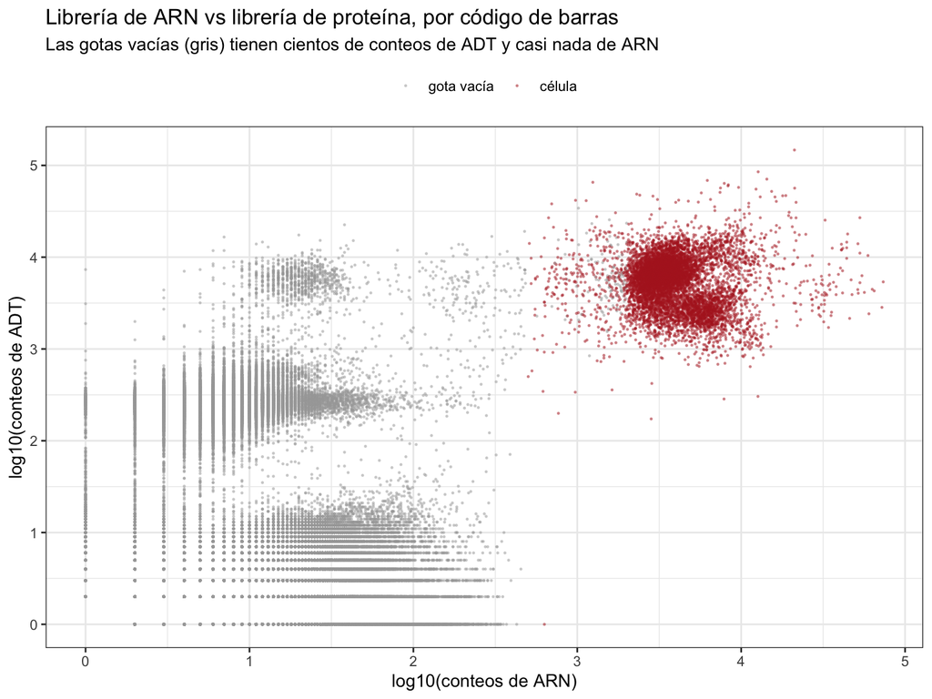

| Anticuerpo | Gota vacía | Célula típica | Fondo |
| --- | --- | --- | --- |
| CD3 | 10 | 812 | 1 % |
| CD4 | 9 | 322 | 3 % |
| CD45RA | 38 | 602 | 6 % |
| CD8a | 7 | 28 | 25 % |
| CD14 | 16 | 37 | 43 % |
| CD16 | 18 | 41 | 44 % |
| CD19 | 2 | 5 | 40 % |
| CD15 | 88 | 106 | 83 % |
| IgG1 (isotipo) | 5 | 11 | 45 % |

En total, el fondo es ~4–5 % de una célula. Pero en los anticuerpos cuyo antígeno la mayoría de las células **no** tiene, la célula típica mide casi lo mismo que una gota vacía.

## Cuando ves 90 conteos de CD15 en un linfocito T, no sabes si son 90 de fondo o 85 de fondo y 5 de señal

La consecuencia

Y como las gotas vacías miden **exactamente** ese fondo, tenemos un estimador directo de él.

Esa es la idea completa de dsb.

Por qué es raro

#### El ruido es medible

Es un caso poco habitual en estadística: el ruido se puede medir de forma independiente de la señal.

## CLR vs dsb

Normalización

CLR

#### centered log-ratio

Divide cada conteo por la media geométrica de la célula y toma logaritmo. Es la transformación estándar para datos composicionales.

✅ Corrige diferencias de profundidad de la librería de ADT

❌ No hace **nada** respecto del fondo

❌ La población negativa queda en una posición distinta para cada anticuerpo: no hay umbral común

dsb

#### denoised and scaled by background

1. Estima el fondo específico de cada anticuerpo **a partir de las gotas vacías** y lo resta. 2) Estima y elimina por regresión el ruido técnico específico de cada célula.

✅ Un valor ≈ 0 significa “indistinguible del fondo”, para **todos** los anticuerpos

✅ Permite umbrales interpretables, como en citometría

⚠ Necesita la matriz raw (o `ModelNegativeADTnorm()` si no la tienes)

## Crudo, CLR y dsb sobre los mismos anticuerpos

En nuestros datos

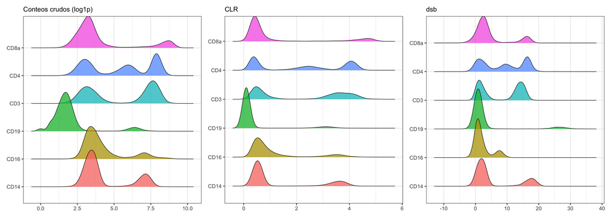

Con dsb, la población negativa queda cerca de 0 en los seis anticuerpos: 0 significa “igual al fondo” para todos. CD4 muestra además tres niveles: negativos, monocitos (~10) y linfocitos T CD4 (~16).

## CD4 vs CD8a: la lectura de un citómetro

En nuestros datos

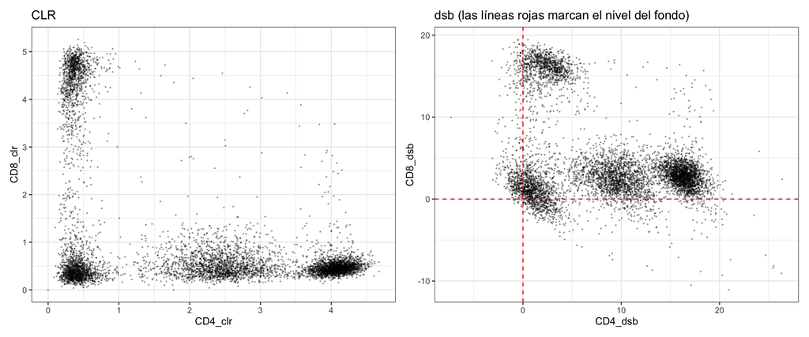

Con dsb

#### Cuadrantes con sentido

CD8+CD4− arriba a la izquierda, CD4+CD8− abajo a la derecha, doble negativo en el origen: las líneas rojas marcan el fondo.

La nube del medio

#### CD4 intermedio = monocitos

Con CLR queda como un reguero entre extremos; con dsb es un nivel propio.

## Cuál usar según la situación

Panorama de métodos

| Método | Cuándo | Nota |
| --- | --- | --- |
| **dsb** | Tienes la matriz raw con gotas vacías | Opción por defecto. Versión 2.0.1 (nov 2025): `fast.km`, ~10× más rápido |
| **`dsb::ModelNegativeADTnorm()`** | Solo tienes la matriz filtrada | Modela la población negativa directamente |
| **ADTnorm** | Vas a integrar varios lotes o estudios | *Nat Commun* 2025. Alinea los picos negativo y positivo entre datasets |
| **CLR** | Comparación rápida, o replicar un análisis viejo | Sigue siendo el default de Seurat; conócelo, pero no lo uses a ciegas |
| **totalVI** | Quieres un modelo generativo conjunto ARN + proteína | Python (scvi-tools). Modela el fondo como parte del modelo |

En este dataset usamos dsb porque se cumplen sus dos condiciones: tenemos la matriz raw con gotas vacías y el panel trae tres controles isotipo.

## Integración multimodal

03

Dos vistas de las mismas células.

## Integrar no es concatenar

Estrategias

**Opción A: concatenar las matrices**  
20.000 genes contra 17 proteínas. La proteína queda enterrada y el resultado es indistinguible de un análisis de solo ARN.

**Opción B: analizar cada modalidad por separado**  
Dos UMAPs y dos clusterings que no se hablan entre sí.

**Opción C: ponderar por célula — WNN**  
*Weighted Nearest Neighbors* aprende, **para cada célula individualmente**, cuánto pesa cada modalidad.

La intuición

#### Depende de qué célula sea

Para separar un monocito de un linfocito T, el ARN alcanza y sobra: son linajes transcripcionalmente muy distintos.

Para separar T CD4 naive de T CD4 de memoria, la proteína (CD45RA, CD45RO, CD127) es mucho más informativa: transcripcionalmente son casi idénticas.

WNN no elige una modalidad para todo el dataset. Elige célula por célula.

## El flujo de WNN en Seurat v5

Implementación

**1 · Procesar cada modalidad por separado, con su propio método**  
ARN: `NormalizeData` → `FindVariableFeatures` → `ScaleData` → `RunPCA`. Proteína: dsb → `ScaleData` → `RunPCA(reduction.name = "apca")`.

**2 · `FindMultiModalNeighbors()`**  
`reduction.list = list("pca", "apca")`, `dims.list = list(1:30, 1:15)`. Construye el grafo ponderado y guarda el peso de cada modalidad por célula.

**3 · UMAP y clustering sobre el grafo ponderado**  
`RunUMAP(nn.name = "weighted.nn")`; `FindClusters(graph.name = "wsnn", algorithm = 4)` — Leiden, como en la clase 2.

**4 · Interpretar los pesos**  
`RNA.weight` es un número por célula entre 0 y 1. No es un parámetro técnico: es un resultado.

## Solo ARN, solo proteína y WNN

En nuestros datos

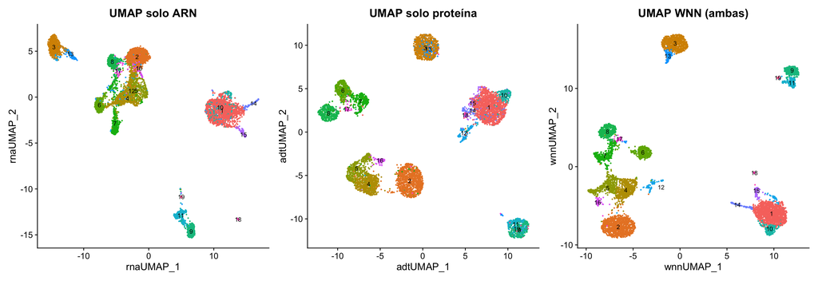

Los mismos 19 clusters (Leiden sobre el grafo WNN) en los tres mapas. El ARN solo mezcla las subpoblaciones de linfocitos T CD4 (2, 4, 5 y 16); la proteína sola funde B y monocitos en pocas islas; WNN separa las dos cosas.

## Los pesos de modalidad son un resultado biológico

Interpretación

`VlnPlot(obj, "RNA.weight", group.by = "cluster", sort = TRUE)`

**Clusters con peso de ARN bajo.** La proteína aportó más: subpoblaciones de linfocitos T, transcripcionalmente muy parecidas entre sí y bien separadas por marcadores de superficie.

**Clusters con peso de ARN alto.** El ARN ya alcanzaba: DC convencionales y plasmacitoides, monocitos CD16+, B de memoria, con perfiles transcripcionales muy distintivos.

**Ojo:** un artefacto de la proteína también baja el peso del ARN.

Puente con el módulo siguiente

#### La misma función, otras modalidades

En datos Multiome se usa `FindMultiModalNeighbors()` para combinar ARN y accesibilidad de cromatina.

Cambian las modalidades. El método es exactamente el mismo.

Y `FindTransferAnchors()`, de la clase 3, reaparece para transferir etiquetas entre modalidades.

## Los pesos de modalidad, cluster por cluster

En nuestros datos

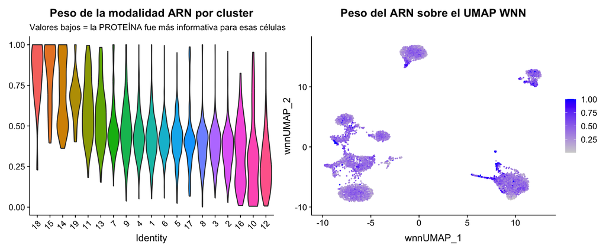

Peso de ARN alto (izquierda)

#### Mieloides raros y B memoria

DC, pDC, monocitos CD16+ y B de memoria: ARN muy distintivo, pocos anticuerpos propios en el panel.

Los dos más bajos (derecha)

#### Clusters 10 y 12: artefactos

Isotipo alto y agregados. La proteína los separó, pero no es biología nueva.

## CD4: el mismo gen, dos mediciones

En nuestros datos

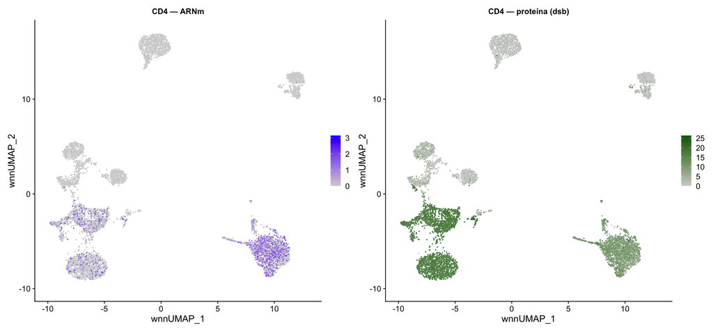

El ARNm de CD4 se ve en los monocitos y casi nada en los T CD4. La proteína marca nítida toda la población T CD4 y, más tenue, a los monocitos: el mismo patrón biológico, sin dropout.

## Anotar con proteína: qué cambia

El pago de todo el trabajo

Qué se hace

#### DotPlot de los 17 ADT y FindAllMarkers sobre ADTdsb

✅ Los marcadores son los de la inmunología clásica: CD4, CD8a, CD19, CD25

✅ Con dsb los valores son comparables entre anticuerpos: se puede poner un umbral

❌ Solo ves lo que pusiste en el panel: 17 proteínas contra 20.000 genes

Cómo se interpreta

#### Se contrasta con la anotación por ARN de la clase 3, célula por célula

✅ Donde coinciden, la anotación queda confirmada por dos medidas independientes

✅ En los linajes T, la proteína suele resolver lo que el ARN no separa

⚠ Un desacuerdo no es un error: es una pregunta que se resuelve con evidencia

⚠ La proteína también tiene artefactos: isotipo alto y agregados

## La anotación multimodal

En nuestros datos

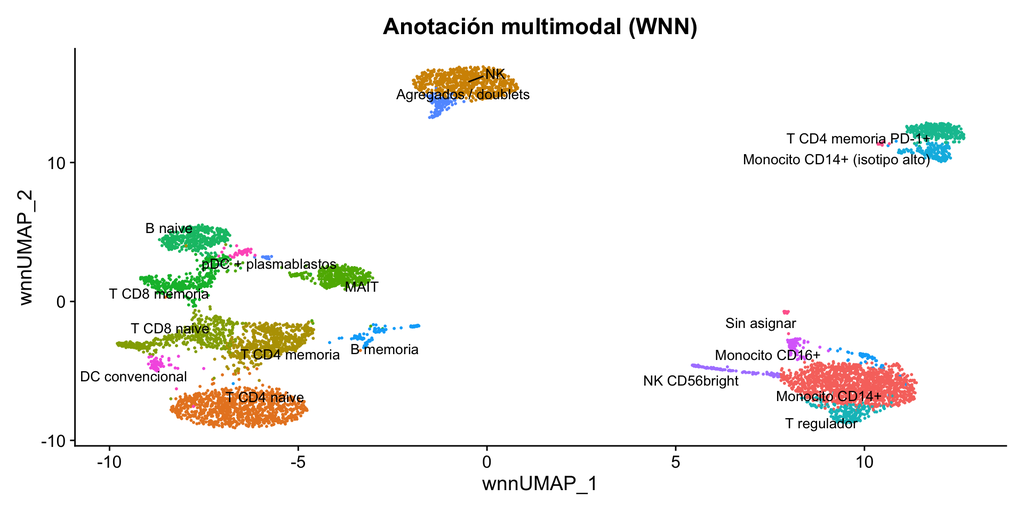

Lo que aporta la proteína

#### Tres poblaciones T nuevas

Un cluster T CD4 con CD25 alto, PD-1 y TIGIT (reguladores y activados), y la separación limpia de naive y memoria en CD4 y CD8.

Lo que hay que descartar

#### Dos clusters técnicos

Clusters 10 (isotipo alto) y 12 (agregados): se etiquetan como tales, no como tipos celulares.

## El perfil de superficie de cada cluster

En nuestros datos

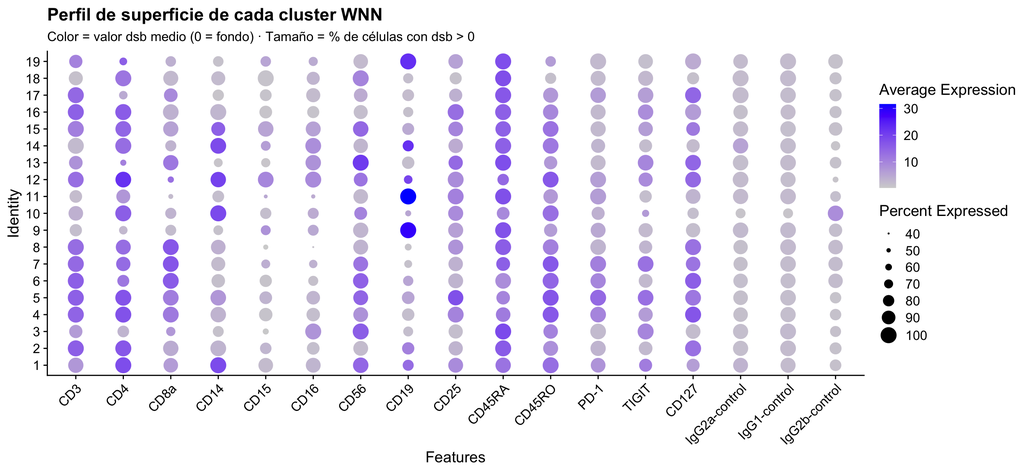

[figure not shown]

[figure not shown]

Cluster 10

#### Isotipo alto

Monocitos que pegan anticuerpo de forma inespecífica.

Cluster 12

#### Agregados / doublets

CD3 + CD4 + CD14 + CD15 + CD16 a la vez.

## ARN (clase 3) vs multimodal (clase 4), célula por célula

En nuestros datos

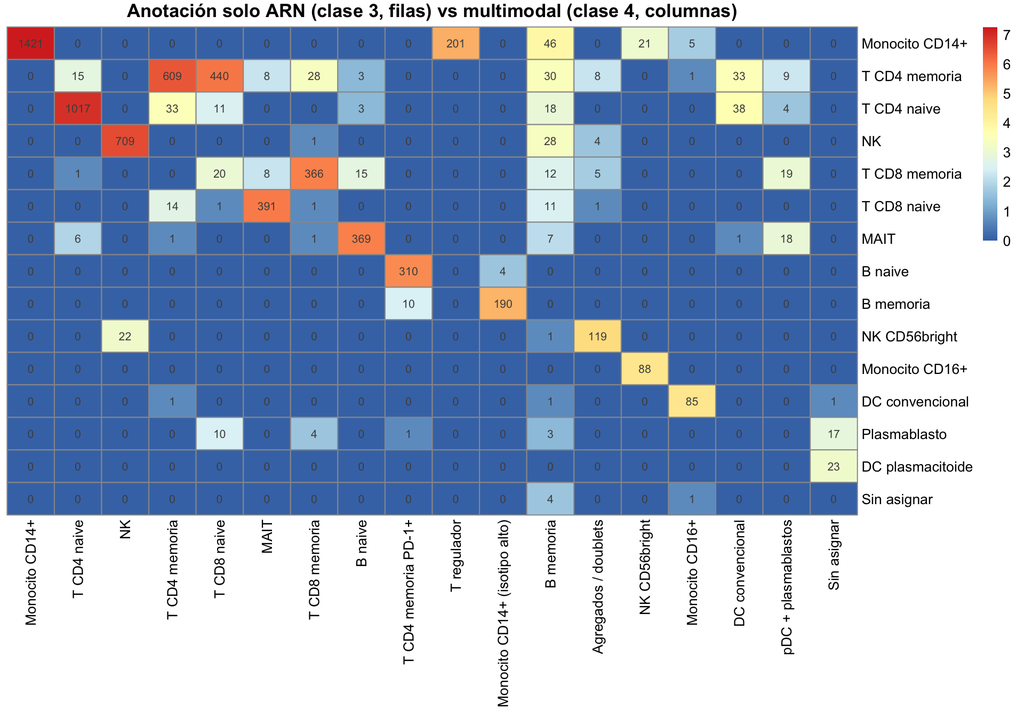

Se abre en dos

#### “T CD4 memoria”

Se parte por un artefacto

#### “Monocito CD14+”

Detectado por la proteína

## La proteína resuelve la anotación dudosa

Cierre del arco de la clase 3

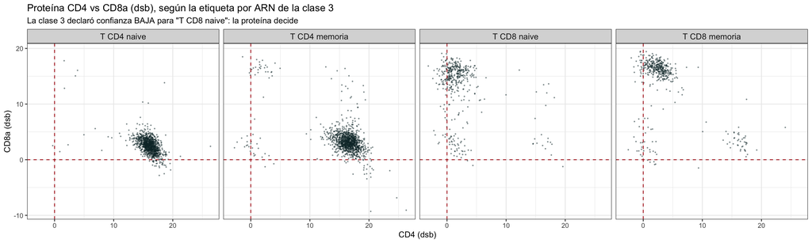

[output not shown]

## Seis cosas

Síntesis de la clase

1. En ADT el ruido dominante es el **fondo**, no el dropout. Es la inversión exacta del problema del ARN.
2. **Las gotas vacías miden el fondo directamente.** Esa observación es la base de dsb.
3. **CLR** corrige profundidad; **dsb** corrige fondo y devuelve valores donde el 0 significa algo.
4. **WNN** pondera las modalidades por célula, y esos pesos son interpretables biológicamente.
5. La proteína recupera marcadores —CD4 es el caso de manual— que el ARNm no ve, y resuelve anotaciones dudosas.
6. **La proteína también tiene artefactos propios:** unión inespecífica y agregados. Un peso de proteína alto no garantiza biología.

## Lo que hay que llevarse de las cuatro clases

Cierre del módulo

| Clase | La idea |
| --- | --- |
| **1** | Normalizar y reducir dimensiones **determina** la estructura que después vas a interpretar. UMAP es un mapa, no una medición. |
| **2** | El clustering siempre devuelve clusters. Los p-valores post-clustering no son p-valores. Para comparar condiciones: pseudobulk. |
| **3** | La anotación celular es una hipótesis. Se sostiene con evidencia convergente y se reporta con su nivel de confianza. |
| **4** | Cada modalidad tiene su propia estructura de ruido. Integrar no es concatenar. |

En el módulo de scATAC-seq que viene después van a reencontrar casi todo lo de estas cuatro clases, aplicado a la cromatina.

Inicio